# Resumption Lags

## Include necessary packages and load data

```r
library(WRS2)
library(rcompanion)
library(feather)
library(ggplot2)
library(plyr)
library(ez)
library(schoRsch)
library(MASS)
library(car)
library(ggpubr)
library(rstatix)
library(DescTools)
library(tidyverse)
library(lsmeans)
library(here)
```

## Load the data

We are loading the experimetal data in long format.

df_long has one row per trial per participant (so three rows per participant for interruption 1, 2, 3).

```r
df_long <- read_feather(path = here('../../data_frames/results_test_18-03-2020_messwdh.file'))
```

```
Coercing int64 to doubleCoercing int64 to doubleCoercing int64 to doubleCoercing int64 to double
```

## Prepare the data

### Assign participants to the experimental group

- version 1 and 2 –> control group
- version 3 und 4 –> experimental group context free
- version 5 und 6–> experimental group context sensitive

```r
df_long$group <- ifelse((df_long$version == 5 | df_long$version == 6), 'context-sensitive experimental group', ifelse((df_long$version == 1 | df_long$version == 2), 'control group', 'context-free experimental group'))
```

### Convert trial, group and subject number to factors in each dataframe

```r
df_long$trial <- factor(df_long$trial, levels=c(1,2,3), labels=c('1','2','3'))
df_long$group <- factor(df_long$group)
df_long$partnr <- factor(df_long$partnr)
```

### Resumption lags

resumption lag = time from the moment that the order list is opened in the browser (after the interruption) until the moment when test participants press a key or do a mouse click (in ms). We analyse absolute time and time relative to the average inter-click intervals, measured during the last two minutes of the primary task (minus / divided by the average time).

Analysing distribution characteristics for raw, log-transformed and inverted resumption lags indicate that resumption speed (1/resumption lags) has the best distribution characteristics and shall therefore be used for the subsequent analysis. The analysis revealed significant main effects of group and trial.

##### Boxplot of resumption lags (identify outliers)

```
`fun.y` is deprecated. Use `fun` instead.
```

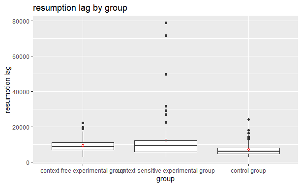

```r
ggplot(df_long,aes(x = group, y=resumption_lags) ) +
  geom_boxplot() +
  stat_summary(fun.y=mean,shape=1,col='red',geom='point') +
  labs(x="group",
       y = "resumption lag",
       title="resumption lag by group")
```

compute split-plots anova for resumption lags

```r
sp_reslag_anova <- aov(resumption_lags ~ trial*group + Error(partnr/(trial)), data=df_long)
summary(sp_reslag_anova)
```

```
Error: partnr
          Df    Sum Sq   Mean Sq F value Pr(>F)
group      2 9.116e+08 455804421   3.986 0.0245 *
Residuals 52 5.946e+09 114344938
---
Signif. codes:  0 ‘***’ 0.001 ‘**’ 0.01 ‘*’ 0.05 ‘.’ 0.1 ‘ ’ 1

Error: partnr:trial
             Df    Sum Sq   Mean Sq F value Pr(>F)
trial         2 2.565e+08 128252857   1.803  0.170
trial:group   4 1.094e+08  27343038   0.384  0.819
Residuals   104 7.397e+09  71126184
```

```r
res_lag_anova = ezANOVA(
data = df_long
, dv = resumption_lags
, wid = partnr
, within = trial
, between = group
, detailed = TRUE
, type = 3
)
```

```
Data is unbalanced (unequal N per group). Make sure you specified a well-considered value for the type argument to ezANOVA().
```

```r
anova_out(res_lag_anova)
```

```
$`--- ANOVA RESULTS     ------------------------------------`
       Effect       MSE df1 df2      F     p petasq getasq
1 (Intercept) 114344938   1  52 132.78 0.000   0.72   0.53
2       group 114344938   2  52   3.99 0.025   0.13   0.06
3       trial  71126184   2 104   1.41 0.248   0.03   0.01
4 group:trial  71126184   4 104   0.38 0.819   0.01   0.01

$`--- SPHERICITY TESTS  ------------------------------------`
       Effect p_Mauchly GGEpsilon  p_GG HFEpsilon  p_HF
1       trial     0.000     0.636 0.245     0.644 0.245
2 group:trial     0.000     0.636 0.732     0.644 0.734

$`--- FORMATTED RESULTS ------------------------------------`
       Effect                                    Text
1 (Intercept)  F(1, 52) = 132.78, p < .001, np2 = .72
2       group  F(2, 52) =   3.99, p = .025, np2 = .13
3       trial F(2, 104) =   1.41, p = .245, np2 = .03
4 group:trial F(4, 104) =   0.38, p = .732, np2 = .01

$`NOTE:`
[1] "p-values for the following effects were GG-adjusted (p_Mauchly <= 0.05): trial; group:trial. Reporting uncorrected degrees of freedom."
```

##### Test requirements for ANOVA

check normal distribution assumption by plotting residuals

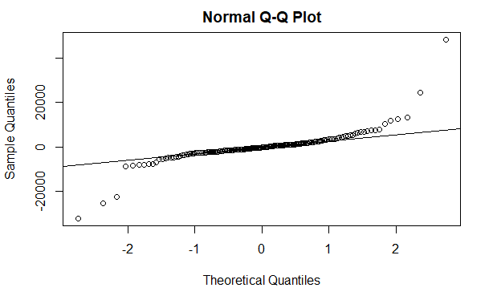

```r
aov_reslag.pr <- proj(sp_reslag_anova)
reslag_res <- aov_reslag.pr[[3]][, "Residuals"]
qqnorm(reslag_res); qqline(reslag_res)
```

Run Shapiro-Wilk test

```r
shapiro.test(x = reslag_res )
```

```
    Shapiro-Wilk normality test

data:  reslag_res
W = 0.70682, p-value < 2.2e-16
```

Run Levene test for homogeneity of variance across groups

```r
leveneTest(df_long$resumption_lags~df_long$group)
```

```
Levene's Test for Homogeneity of Variance (center = median)
       Df F value  Pr(>F)
group   2  4.7131 0.01024 *
      162
---
Signif. codes:  0 ‘***’ 0.001 ‘**’ 0.01 ‘*’ 0.05 ‘.’ 0.1 ‘ ’ 1
```

The tests indicate that the requirements for ANOVA are not met. Therefore, we compute robust ANOVA. Robust ANOVA for resumption lags yields significant effects of trial and group.

```r
bwtrim(resumption_lags ~ group*trial, id = partnr, data = df_long)
```

```
Call:
bwtrim(formula = resumption_lags ~ group * trial, id = partnr,
    data = df_long)
```

|  | value | df1 | df2 | p.value |
| --- | --- | --- | --- | --- |
| group | 5.6962 | 2 | 14.9479 | 0.0145 |
| trial | 7.6896 | 2 | 19.4950 | 0.0035 |
| group:trial | 0.7603 | 4 | 15.5606 | 0.5665 |

```
NA
```

Test contrasts

```r
sppbi(formula = resumption_lags~ group * trial, id = partnr, data = df_nasa)
```

```
Call:
sppbi(formula = resumption_lags ~ group * trial, id = partnr,
    data = df_nasa)

Test statistics:
```

|  | Estimate |
| --- | --- |
| context-free experimental group 0-1 | 779.5855 |
| context-free experimental group 0-2 | -2621.5812 |
| context-free experimental group 0-3 | -3401.1667 |
| context-free experimental group 1-2 | 889.9856 |
| context-free experimental group 1-3 | -1053.1722 |
| context-free experimental group 2-3 | -1943.1579 |
| context-sensitive experimental group 0-1 | -1546.7639 |
| context-sensitive experimental group 0-2 | -2907.3750 |
| context-sensitive experimental group 0-3 | -1360.6111 |
| context-sensitive experimental group 1-2 | -1290.8077 |

[output cut: 8 more lines]

```
Test whether the corrresponding population parameters are the same:
p-value: 0.432
```

Plot interaction

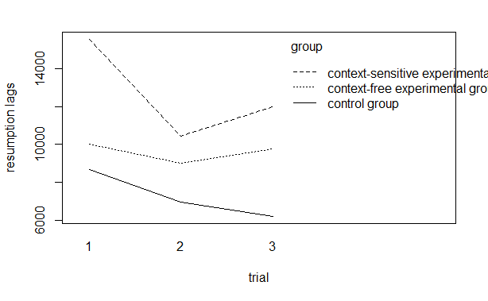

```r
interaction.plot(df_long$`trial`, df_long$group, df_long$resumption_lags, xlab = 'trial', ylab = 'resumption lags', trace.label = 'group', cex=1.3, pch=1, pt.cex = 1)
```

##### Test normal distribution assumptions for log-transformed data

log-transform the data

```r
df_long$reslags_log <- log(df_long$resumption_lags)
```

Compute split-plots anova for log-transformed resumption lags

```r
reslags_log_anova <- aov(reslags_log ~ trial*group + Error(partnr/(trial)), data=df_long)
summary(reslags_log_anova)
```

```
Error: partnr
          Df Sum Sq Mean Sq F value Pr(>F)
group      2   3.97  1.9850   4.754 0.0127 *
Residuals 52  21.71  0.4175
---
Signif. codes:  0 ‘***’ 0.001 ‘**’ 0.01 ‘*’ 0.05 ‘.’ 0.1 ‘ ’ 1

Error: partnr:trial
             Df Sum Sq Mean Sq F value  Pr(>F)
trial         2  3.138  1.5691   6.061 0.00324 **
trial:group   4  0.564  0.1409   0.544 0.70361
Residuals   104 26.923  0.2589
---
Signif. codes:  0 ‘***’ 0.001 ‘**’ 0.01 ‘*’ 0.05 ‘.’ 0.1 ‘ ’ 1
```

Check normal distribution assumption by plotting residuals

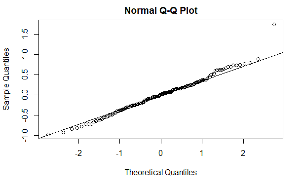

```r
aov_reslags_log.pr <- proj(reslags_log_anova)
reslaglog_res <- aov_reslags_log.pr[[3]][, "Residuals"]
qqnorm(reslaglog_res); qqline(reslaglog_res)
```

The QQplots look more normally distributed but there is one extreme outlier.

Run Shapiro-Wilk test

```r
shapiro.test(x = reslaglog_res )
```

```
    Shapiro-Wilk normality test

data:  reslaglog_res
W = 0.98192, p-value = 0.02999
```

Run Levene test for homogeneity of variance across groups

```r
leveneTest(df_long$reslags_log~df_long$group)
```

```
Levene's Test for Homogeneity of Variance (center = median)
       Df F value  Pr(>F)
group   2   4.693 0.01044 *
      162
---
Signif. codes:  0 ‘***’ 0.001 ‘**’ 0.01 ‘*’ 0.05 ‘.’ 0.1 ‘ ’ 1
```

The tests indicate that the requirements for ANOVA are not met.

##### Test normal distribution assumptions for 1/resumption lags (speed)

A significant main effect of group and trial emerges.

```r
#transform the data
df_long$res_speed <- 1/df_long$resumption_lags
```

```r
res_speed_anova <- aov(res_speed ~ trial*group + Error(partnr/(trial)), data=df_long)
summary(res_speed_anova)
```

```
Error: partnr
          Df    Sum Sq   Mean Sq F value Pr(>F)
group      2 3.816e-08 1.908e-08   3.205 0.0487 *
Residuals 52 3.096e-07 5.954e-09
---
Signif. codes:  0 ‘***’ 0.001 ‘**’ 0.01 ‘*’ 0.05 ‘.’ 0.1 ‘ ’ 1

Error: partnr:trial
             Df    Sum Sq  Mean Sq F value  Pr(>F)
trial         2 6.520e-08 3.26e-08   7.186 0.00119 **
trial:group   4 7.200e-09 1.81e-09   0.399 0.80890
Residuals   104 4.717e-07 4.54e-09
---
Signif. codes:  0 ‘***’ 0.001 ‘**’ 0.01 ‘*’ 0.05 ‘.’ 0.1 ‘ ’ 1
```

```r
aov_res_speed <- ezANOVA(
  data = df_long
  , dv = res_speed
  , wid = partnr
  , within = trial
  , between = group
  , detailed = TRUE
  , return_aov = TRUE
  , type = 3
)
```

```
Data is unbalanced (unequal N per group). Make sure you specified a well-considered value for the type argument to ezANOVA().
```

```r
anova_out(aov_res_speed)
```

```
$`--- ANOVA RESULTS     ------------------------------------`
       Effect          MSE df1 df2      F     p petasq getasq
1 (Intercept) 5.953618e-09   1  52 541.90 0.000   0.91   0.81
2       group 5.953618e-09   2  52   3.20 0.049   0.11   0.05
3       trial 4.535987e-09   2 104   6.14 0.003   0.11   0.07
4 group:trial 4.535987e-09   4 104   0.40 0.809   0.02   0.01

$`--- SPHERICITY TESTS  ------------------------------------`
       Effect p_Mauchly GGEpsilon  p_GG HFEpsilon  p_HF
1       trial     0.099     0.920 0.004     0.952 0.004
2 group:trial     0.099     0.920 0.793     0.952 0.800

$`--- FORMATTED RESULTS ------------------------------------`
       Effect                                    Text
1 (Intercept)  F(1, 52) = 541.90, p < .001, np2 = .91
2       group  F(2, 52) =   3.20, p = .049, np2 = .11
3       trial F(2, 104) =   6.14, p = .003, np2 = .11
4 group:trial F(4, 104) =   0.40, p = .809, np2 = .02

$`NOTE:`
[1] "No adjustments necessary (all p_Mauchly > 0.05)."
```

Check normal distribution assumption by plotting residuals

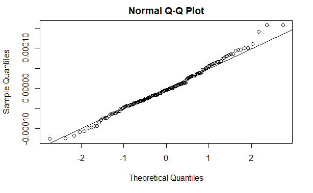

```r
aov_res_speed.pr <- proj(res_speed_anova)
reslagspeed_res <- aov_res_speed.pr[[3]][, "Residuals"]
qqnorm(reslagspeed_res); qqline(reslagspeed_res)
```

Run Shapiro-Wilk test

```r
shapiro.test(x = reslagspeed_res )
```

```
    Shapiro-Wilk normality test

data:  reslagspeed_res
W = 0.98909, p-value = 0.2326
```

Run levene test for homogenity of variance across groups

```r
leveneTest(df_long$res_speed~df_long$group)
```

```
Levene's Test for Homogeneity of Variance (center = median)
       Df F value Pr(>F)
group   2  1.1421 0.3217
      162
```

QQplot of the residuals and the results of the Levene test indicate that the assumption of normal distribution and variance homogenity are met. Resumption speed meets the assumptions for ANOVA best and shall therefore be used for the subsequent analysis.

##### Plot resumption speed

Boxplot for resumption speed per group

```
`fun.y` is deprecated. Use `fun` instead.
```

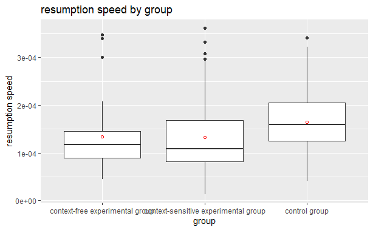

```r
ggplot(df_long,aes(x = group, y=res_speed) ) +
  geom_boxplot() +
  stat_summary(fun.y=mean,shape=1,col='red',geom='point') +
  labs(x="group",
       y = "resumption speed",
       title="resumption speed by group")
```

interaction plot

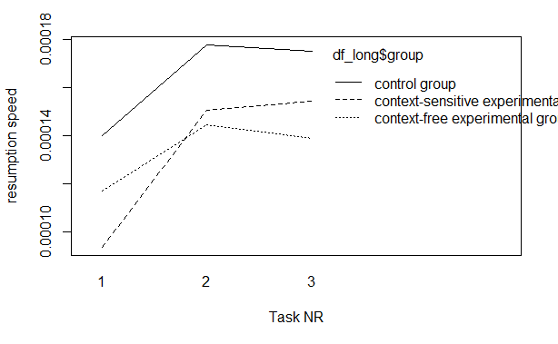

```r
interaction.plot(df_long$trial, df_long$group, df_long$res_speed, xlab = 'Task NR', ylab = 'resumption speed')
```

### Post-hoc analyis using pairwise paired t-tests

```r
pwc_trial <- df_long%>%
  pairwise_t_test(
    res_speed ~ trial, paired = TRUE,
    p.adjust.method = "holm"
    )
pwc_trial
```

|  | .y. | group1 | group2 | n1 | n2 | statistic | df | p | p.adj | p.adj.signif |
| --- | --- | --- | --- | --- | --- | --- | --- | --- | --- | --- |
| 1 | res_speed | 1 | 2 | 55 | 55 | -3.93831563 | 54 | 0.000237 | 0.000711 | *** |
| 2 | res_speed | 1 | 3 | 55 | 55 | -3.17008002 | 54 | 0.003000 | 0.005000 | ** |
| 3 | res_speed | 2 | 3 | 55 | 55 | 0.05751075 | 54 | 0.954000 | 0.954000 | ns |

#### Compare results from the Anova with a mixed linear model.

```r
library(nlme)
lm.res_lags <- lme(res_speed ~ group*trial, data = df_long, random = ~1|partnr, correlation = corCompSymm(form = ~1|partnr))
anova(lm.res_lags, type="marginal")
```

|  | numDF | denDF | F-value | p-value |
| --- | --- | --- | --- | --- |
| (Intercept) | 1 | 104 | 35.37715 | <.0001 |
| group | 2 | 52 | 2.24979 | 0.1156 |
| trial | 2 | 104 | 0.61297 | 0.5437 |
| group:trial | 4 | 104 | 0.39909 | 0.8089 |

#### Compute contrasts between control group and both experimental groups / only the context-sensitive experimental group

The contrast between control group and both experimental groups reaches statistical significance. The other contrast does not.

```r
leastsquare = lsmeans(lm.res_lags, "group")
```

```
NOTE: Results may be misleading due to involvement in interactions
```

```r
Contrasts = list(ControlvsExp = c(-1, -1, 2),
                 ControlvsExpContext = c(0, -1, 1))
contrast(leastsquare, Contrasts, adjust="sidak")
```

```
 contrast            estimate       SE df t.ratio p.value
 ControlvsExp        6.24e-05 2.50e-05 52 2.498   0.0312
 ControlvsExpContext 3.15e-05 1.37e-05 52 2.294   0.0511

Results are averaged over the levels of: trial
Degrees-of-freedom method: containment
P value adjustment: sidak method for 2 tests
```

#### Descriptive data

```r
df_long %>%
  group_by(trial, group) %>%
  summarise(M_res = mean(res_speed),
            SD_res = sd(res_speed))
```

| trial | group | M_res | SD_res |
| --- | --- | --- | --- |
| 1 | context-free experimental group | 1.167468e-04 | 4.932793e-05 |
| 1 | context-sensitive experimental group | 9.364063e-05 | 4.701530e-05 |
| 1 | control group | 1.399689e-04 | 5.683809e-05 |
| 2 | context-free experimental group | 1.443747e-04 | 6.876906e-05 |
| 2 | context-sensitive experimental group | 1.503046e-04 | 9.108215e-05 |
| 2 | control group | 1.776685e-04 | 6.937333e-05 |
| 3 | context-free experimental group | 1.388769e-04 | 9.508922e-05 |
| 3 | context-sensitive experimental group | 1.541815e-04 | 9.006191e-05 |
| 3 | control group | 1.750997e-04 | 5.179898e-05 |

#### Plot the data per group and trial

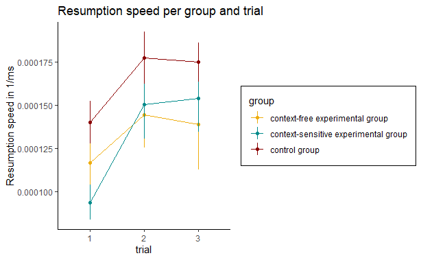

```r
#detach("package:ggpubr", unload=TRUE)
#detach("package:rstatix", unload=TRUE)
library(dplyr)
df_long %>%
  group_by(trial,group) %>%
  summarise(res_speed_groups = mean(res_speed),
            res_speed_sem = (sd(res_speed)/sqrt(length(res_speed)))) -> df_rs
df_rs %>%
  ggplot() +
  theme_classic() +
  aes(x = trial, y = res_speed_groups, colour = group) +
  geom_line(aes(group = group)) +
  scale_color_manual(values =  c('darkgoldenrod2', 'darkcyan', 'darkred')) +
  geom_point() +
  geom_linerange(aes(x = trial, ymin = res_speed_groups - res_speed_sem, ymax = res_speed_groups + res_speed_sem), size = .3) +
  theme(legend.box.background = element_rect(),
  legend.box.margin = margin(4, 4, 4, 4)) +
  labs(title = "Resumption speed per group and trial", y = "Resumption speed in 1/ms")
```

```r
  scale_y_continuous(limits = c(0,0.0003))
```

```
<ScaleContinuousPosition>
 Range:
 Limits:    0 -- 0.0003
```

### Test resumption lags relative to average interclick-intervals

#### Analysis of resumption lag minus the average interclick-intervall (disruption score)

The data is difficult to interpret due to a high number of outliers. Also, the assumptions for homogenity of variance and normal distribution are both violated. It shall therefore be excluded from the final analysis.

```r
disruptionscore_anova = ezANOVA(
data = df_long
, dv = resumption_lags_alt1
, wid = partnr
, within = factor(trial)
, between = group
, detailed = TRUE
, type = 3
, return_aov = TRUE
)
```

```
Data is unbalanced (unequal N per group). Make sure you specified a well-considered value for the type argument to ezANOVA().
```

```r
anova_out(res_lag_alt1_anova)
```

```
$`--- ANOVA RESULTS     ------------------------------------`
       Effect          MSE df1 df2    F     p petasq getasq
1 (Intercept) 0.0008665358   1  52 2.80 0.100   0.05   0.02
2       group 0.0008665358   2  52 1.83 0.171   0.07   0.02
3       trial 0.0008857584   2 104 1.34 0.266   0.03   0.02
4 group:trial 0.0008857584   4 104 1.61 0.179   0.06   0.04

$`--- SPHERICITY TESTS  ------------------------------------`
       Effect p_Mauchly GGEpsilon  p_GG HFEpsilon  p_HF
1       trial     0.000     0.540 0.255     0.542 0.255
2 group:trial     0.000     0.540 0.208     0.542 0.208

$`--- FORMATTED RESULTS ------------------------------------`
       Effect                                  Text
1 (Intercept)  F(1, 52) = 2.80, p = .100, np2 = .05
2       group  F(2, 52) = 1.83, p = .171, np2 = .07
3       trial F(2, 104) = 1.34, p = .255, np2 = .03
4 group:trial F(4, 104) = 1.61, p = .208, np2 = .06

$`NOTE:`
[1] "p-values for the following effects were GG-adjusted (p_Mauchly <= 0.05): trial; group:trial. Reporting uncorrected degrees of freedom."
```

Check normal distribution assumption

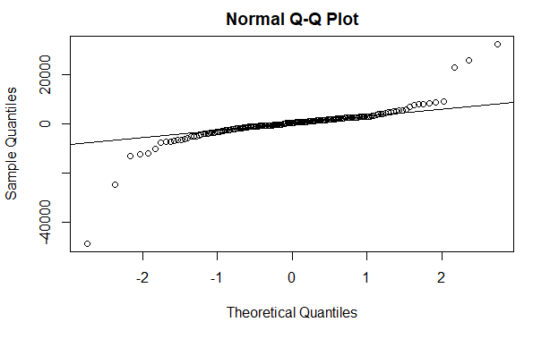

```r
#QQplots
aov_ds.pr <- proj(disruptionscore_anova$aov)
ds_res <- aov_ds.pr[[3]][, "Residuals"]
qqnorm(ds_res); qqline(ds_res)
```

```r
# Run Shapiro-Wilk test
shapiro.test(x = ds_res )
```

[output not shown]

QQplot of the residuals and Shapiro-Wilk test indicates that the assumption of normal distribution is not met.

Levene test for homogeneity of variance across groups

```r
leveneTest(df_long$resumption_lags_alt1~df_long$group)
```

```
Levene's Test for Homogeneity of Variance (center = median)
       Df F value    Pr(>F)
group   2  10.736 4.183e-05 ***
      162
---
Signif. codes:  0 ‘***’ 0.001 ‘**’ 0.01 ‘*’ 0.05 ‘.’ 0.1 ‘ ’ 1
```

Significant Levene Test indicates that variance homogenity is not given. Therefore, we compute a robust ANOVA.

```r
bwtrim(resumption_lags_alt1 ~ group*trial, id = partnr, data = df_long)
```

```
Call:
bwtrim(formula = resumption_lags_alt1 ~ group * trial, id = partnr,
    data = df_long)
```

|  | value | df1 | df2 | p.value |
| --- | --- | --- | --- | --- |
| group | 6.5124 | 2 | 12.3367 | 0.0117 |
| trial | 5.1923 | 2 | 15.2769 | 0.0190 |
| group:trial | 0.0842 | 4 | 15.1339 | 0.9861 |

```
NA
```

Plot the disruption scores

```
`fun.y` is deprecated. Use `fun` instead.
```

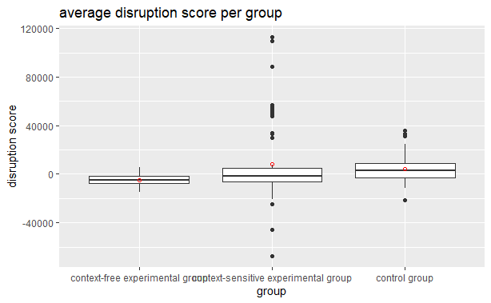

```r
# Boxplot for relative resumption lags per group
ggplot(df_long,aes(x = df_long$'group', y=df_long$'resumption_lags_alt1') ) +
  geom_boxplot() +
  stat_summary(fun.y=mean,shape=1,col='red',geom='point') +
  labs(x="group",
       y = "disruption score",
       title="average disruption score per group")
```

A large number of outliers makes it difficult to interpret the data.

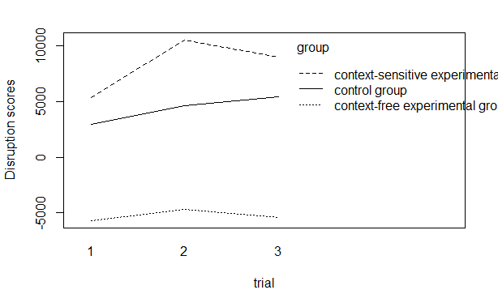

```r
interaction.plot(df_long$`trial`, df_long$group, df_long$resumption_lags_alt1, xlab = 'trial', ylab = 'Disruption scores', trace.label = 'group', cex=1.3, pch=1, pt.cex = 1)
```

```r
## post-hoc analyis using pairwise paired t-tests
pwc <- df_long%>%
  pairwise_t_test(
    res_speed ~ trial, paired = TRUE,
    p.adjust.method = "bonferroni"
    )
pwc
```

|  | .y. | group1 | group2 | n1 | n2 | statistic | df | p | p.adj | p.adj.signif |
| --- | --- | --- | --- | --- | --- | --- | --- | --- | --- | --- |
| 1 | res_speed | 1 | 2 | 55 | 55 | -3.93831563 | 54 | 0.000237 | 0.000711 | *** |
| 2 | res_speed | 1 | 3 | 55 | 55 | -3.17008002 | 54 | 0.003000 | 0.008000 | ** |
| 3 | res_speed | 2 | 3 | 55 | 55 | 0.05751075 | 54 | 0.954000 | 1.000000 | ns |

### post-hoc analyis using pairwise paired t-tests

```r
pwc <- df_long%>%
  pairwise_t_test(
    res_speed ~ trial, paired = TRUE,
    p.adjust.method = "bonferroni"
    )
pwc
```

|  | .y. | group1 | group2 | n1 | n2 | statistic | df | p | p.adj | p.adj.signif |
| --- | --- | --- | --- | --- | --- | --- | --- | --- | --- | --- |
| 1 | res_speed | 1 | 2 | 55 | 55 | -3.93831563 | 54 | 0.000237 | 0.000711 | *** |
| 2 | res_speed | 1 | 3 | 55 | 55 | -3.17008002 | 54 | 0.003000 | 0.008000 | ** |
| 3 | res_speed | 2 | 3 | 55 | 55 | 0.05751075 | 54 | 0.954000 | 1.000000 | ns |

### Analyse resumption lags relative to average interclick-intervals: resumption lag divided by average interclick-interval

```r
res_lag_alt2_anova = ezANOVA(
data = df_long
, dv = resumption_lags_alt2
, wid = partnr
, within = trial
, between = group
, detailed = TRUE
, type = 3
, return_aov = TRUE
)
```

```
Data is unbalanced (unequal N per group). Make sure you specified a well-considered value for the type argument to ezANOVA().
```

```r
anova_out(res_lag_alt2_anova)
```

```
$`--- ANOVA RESULTS     ------------------------------------`
       Effect      MSE df1 df2     F     p petasq getasq
1 (Intercept) 9.977977   1  52 66.62 0.000   0.56   0.47
2       group 9.977977   2  52  1.81 0.174   0.07   0.05
3       trial 2.154343   2 104  2.23 0.112   0.04   0.01
4 group:trial 2.154343   4 104  0.83 0.510   0.03   0.01

$`--- SPHERICITY TESTS  ------------------------------------`
       Effect p_Mauchly GGEpsilon  p_GG HFEpsilon  p_HF
1       trial     0.000     0.707 0.130     0.721 0.129
2 group:trial     0.000     0.707 0.476     0.721 0.478

$`--- FORMATTED RESULTS ------------------------------------`
       Effect                                   Text
1 (Intercept)  F(1, 52) = 66.62, p < .001, np2 = .56
2       group  F(2, 52) =  1.81, p = .174, np2 = .07
3       trial F(2, 104) =  2.23, p = .130, np2 = .04
4 group:trial F(4, 104) =  0.83, p = .476, np2 = .03

$`NOTE:`
[1] "p-values for the following effects were GG-adjusted (p_Mauchly <= 0.05): trial; group:trial. Reporting uncorrected degrees of freedom."
```

```r
## compute split-plots anova for relative resumption lags
reslags_alt2_anova <- aov(resumption_lags_alt2 ~ trial*group + Error(partnr/(trial)), data=df_long)
summary(reslags_alt2_anova)
```

```
Error: partnr
          Df Sum Sq Mean Sq F value Pr(>F)
group      2   36.1  18.058    1.81  0.174
Residuals 52  518.9   9.978

Error: partnr:trial
             Df Sum Sq Mean Sq F value Pr(>F)
trial         2  11.40   5.699   2.646 0.0757 .
trial:group   4   7.14   1.785   0.828 0.5100
Residuals   104 224.05   2.154
---
Signif. codes:  0 ‘***’ 0.001 ‘**’ 0.01 ‘*’ 0.05 ‘.’ 0.1 ‘ ’ 1
```

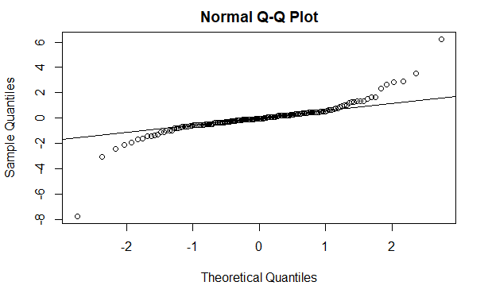

```r
# check normal distribution assumption by plotting residuals
aov_reslags_alt2.pr <- proj(reslags_alt2_anova)
reslagalt2_res <- aov_reslags_alt2.pr[[3]][, "Residuals"]
qqnorm(reslagalt2_res); qqline(reslagalt2_res)
```

```r
# Run Shapiro-Wilk test
shapiro.test(x = reslagalt2_res )
```

```
    Shapiro-Wilk normality test

data:  reslagalt2_res
W = 0.78193, p-value = 2.11e-14
```

```r
# run levene test for homogeneity of variance across groups
leveneTest(df_long$resumption_lags_alt2~df_long$group)
```

```
Levene's Test for Homogeneity of Variance (center = median)
       Df F value Pr(>F)
group   2  0.5677  0.568
      162
```

The tests indicate that the requirements for ANOVA are not fulfilled. Thus, we compute a robust ANOVA.

```r
bwtrim(resumption_lags_alt1 ~ group*trial, id = partnr, data = df_long)
```

```
Call:
bwtrim(formula = resumption_lags_alt1 ~ group * trial, id = partnr,
    data = df_long)
```

|  | value | df1 | df2 | p.value |
| --- | --- | --- | --- | --- |
| group | 6.5124 | 2 | 12.3367 | 0.0117 |
| trial | 5.1923 | 2 | 15.2769 | 0.0190 |
| group:trial | 0.0842 | 4 | 15.1339 | 0.9861 |

```
NA
```

```
`fun.y` is deprecated. Use `fun` instead.
```

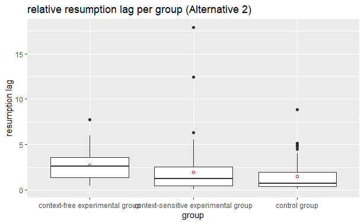

```r
# Boxplot for relative resumption lags per group
ggplot(df_long,aes(x = group, y=resumption_lags_alt2) ) +
  geom_boxplot() +
  stat_summary(fun.y=mean,shape=1,col='red',geom='point') +
  labs(x="group",
       y = "resumption lag",
       title="relative resumption lag per group (Alternative 2)")
```

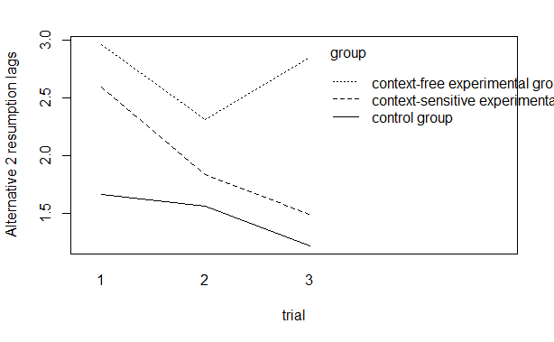

```r
interaction.plot(df_long$`trial`, df_long$group, df_long$resumption_lags_alt2, xlab = 'trial', ylab = 'Alternative 2 resumption lags', trace.label = 'group', cex=1.3, pch=1, pt.cex = 1)
```

#### Exclude outliers

```r
median_reslags_alt2 <- aggregate(resumption_lags_alt2 ~ group, df_long, median)
median_reslags_alt2
```

| group | resumption_lags_alt2 |
| --- | --- |
| context-free experimental group | 2.6208000 |
| context-sensitive experimental group | 1.2274000 |
| control group | 0.7303333 |

```r
sd_reslags_alt2 <- aggregate(resumption_lags_alt2 ~ group, df_long, sd)
sd_reslags_alt2
```

| group | resumption_lags_alt2 |
| --- | --- |
| context-free experimental group | 1.576655 |
| context-sensitive experimental group | 2.807228 |
| control group | 1.696246 |

```r
exclude_outliers_interval <- median_reslags_alt2$resumption_lags_alt2 + 3*sd_reslags_alt2$resumption_lags_alt2
exclude_outliers_interval
```

```
[1] 7.350764 9.649084 5.819072
```

```r
df_res <-df_long[!(df_long$group=="context-free experimental group" & df_long$resumption_lags_alt2>7.35),]
df_res <- df_res[!(df_res$group=="context-sensitive experimental group" & df_res$resumption_lags_alt2>9.65),]
df_res <- df_res[!(df_res$group=="control group" & df_res$resumption_lags_alt2>5.82),]
count(df_res, group)
```

| group | n |
| --- | --- |
| context-free experimental group | 38 |
| context-sensitive experimental group | 61 |
| control group | 62 |

#### Check assumptions for ANOVA

```r
reslags_alt2o_anova <- aov(resumption_lags_alt2 ~ trial*group + Error(partnr/(trial)), data=df_res)
```

[output not shown]

```r
summary(reslags_alt2o_anova)
```

```
Error: partnr
            Df Sum Sq Mean Sq F value Pr(>F)
trial        2   6.18   3.092   0.753 0.4764
group        2  40.81  20.403   4.967 0.0109 *
trial:group  1   2.07   2.074   0.505 0.4807
Residuals   49 201.29   4.108
---
Signif. codes:  0 ‘***’ 0.001 ‘**’ 0.01 ‘*’ 0.05 ‘.’ 0.1 ‘ ’ 1

Error: partnr:trial
             Df Sum Sq Mean Sq F value Pr(>F)
trial         2   7.67   3.834   4.547 0.0129 *
trial:group   4   0.44   0.109   0.130 0.9712
Residuals   100  84.34   0.843
---
Signif. codes:  0 ‘***’ 0.001 ‘**’ 0.01 ‘*’ 0.05 ‘.’ 0.1 ‘ ’ 1
```

Check normal distribution assumption by plotting residuals

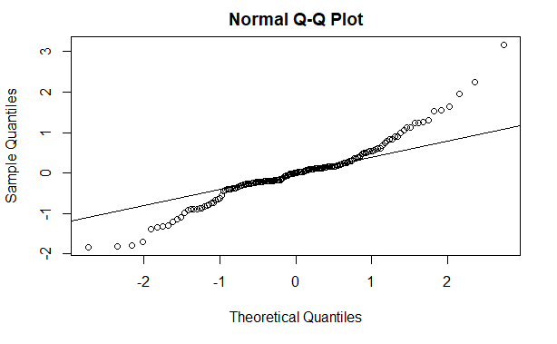

```r
aov_reslags_alt2_o.pr <- proj(reslags_alt2o_anova)
reslagalt2_res_o <- aov_reslags_alt2_o.pr[[3]][, "Residuals"]
qqnorm(reslagalt2_res_o); qqline(reslagalt2_res_o)
```

Run Shapiro-Wilk test

```r
shapiro.test(x = reslagalt2_res_o )
```

```
    Shapiro-Wilk normality test

data:  reslagalt2_res_o
W = 0.94578, p-value = 7.478e-06
```

Run Levene test for homogeneity of variance across groups

```r
leveneTest(df_res$resumption_lags_alt2~df_res$group)
```

```
Levene's Test for Homogeneity of Variance (center = median)
       Df F value Pr(>F)
group   2  0.1529 0.8584
      158
```

QQplot of the residuals and Shapiro-Wilk test indicates that the assumption of normal distribution is not met –> compute robust ANOVA

```r
bwtrim(resumption_lags_alt2 ~ group*trial, id = partnr, data = df_res)
```

```
Call:
bwtrim(formula = resumption_lags_alt2 ~ group * trial, id = partnr,
    data = df_res)
```

|  | value | df1 | df2 | p.value |
| --- | --- | --- | --- | --- |
| trial | 1.7267 | 2 | 18.3532 | 0.2055 |
| group | 8.9136 | 2 | 18.2328 | 0.0020 |
| trial:group | 0.0714 | 4 | 17.4832 | 0.9899 |

```
NA
```

Boxplot and interaction for relative resumption lags per group (after removing outliers)

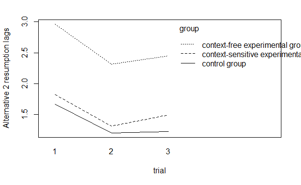

```r
interaction.plot(df_res$`trial`, df_res$group, df_res$resumption_lags_alt2, xlab = 'trial', ylab = 'Alternative 2 resumption lags', trace.label = 'group', cex=1.3, pch=1, pt.cex = 1)
```

After removing the outliers, significant differences between context-free experimental group and the other two groups emerge but no main effect of trial.

### List input lags

Compare how long it takes test participants to make the next order list entry in the order list after an interruption. Untransformed list input lags meet the requirements for ANOVA best. There is a significant main effect of trial but no further significant effects.

##### Replace missing values with median

```r
aggregate(df_long$list_input_lags, by= list(df_long$group),FUN=function(x) {sum(is.na(x))} )
```

| Group.1 | x |
| --- | --- |
| context-free experimental group | 4 |
| context-sensitive experimental group | 7 |
| control group | 6 |

Missing values per test participant

```r
aggregate(df_long$list_input_lags, by= list(df_long$partnr),FUN=function(x) {sum(is.na(x))} )
```

| Group.1 | x |
| --- | --- |
| 1 | 0 |
| 3 | 0 |
| 4 | 1 |
| 6 | 0 |
| 7 | 0 |
| 8 | 1 |
| 9 | 0 |
| 11 | 0 |
| 12 | 0 |
| 13 | 0 |

[output cut: 45 more lines]

Substitute missing values with median

```r
df_list_md <- df_long  %>% select(partnr, trial, group,list_input_lags)
list_exp <- df_list_md$list_input_lags[which(df_list_md$group == "context-sensitive experimental group")]
list_control <- df_list_md$list_input_lags[which(df_list_md$group == "control group")]
list_exp_2 <- df_list_md$list_input_lags[which(df_list_md$group == "context-free experimental group")]
md_exp <- median(list_exp, na.rm = TRUE)
md_control <- median(list_control, na.rm = TRUE)
md_exp_2 <- median(list_exp_2, na.rm = TRUE)
# replace NA's with median
df_list_md$list_input_lags[is.na(df_list_md$list_input_lags) & df_list_md$group == "context-sensitive experimental group"] <- md_exp
df_list_md$list_input_lags[is.na(df_list_md$list_input_lags) & df_list_md$group == "control group"] <- md_control
df_list_md$list_input_lags[is.na(df_list_md$list_input_lags) & df_list_md$group == "context-free experimental group"] <- md_exp_2
## check NA's
## missing values per group
aggregate(df_list_md$list_input_lags, by= list(df_list_md$group),FUN=function(x) {sum(is.na(x))} )
```

| Group.1 | x |
| --- | --- |
| context-free experimental group | 0 |
| context-sensitive experimental group | 0 |
| control group | 0 |

#### Are there differences in how fast test participants make the the first order list entry after an interruption between groups and trials ?

```r
inputlag_anova <- ezANOVA(
data = df_list_md
, dv = list_input_lags
, wid = partnr
, within = trial
, between = group
, detailed = TRUE
, type = 3
, return_aov = TRUE
)
```

```
Data is unbalanced (unequal N per group). Make sure you specified a well-considered value for the type argument to ezANOVA().
```

```r
anova_out(inputlag_anova)
```

```
$`--- ANOVA RESULTS     ------------------------------------`
       Effect        MSE df1 df2      F     p petasq getasq
1 (Intercept) 4447327534   1  52 276.56 0.000   0.84   0.70
2       group 4447327534   2  52   0.62 0.544   0.02   0.01
3       trial 2820885736   2 104   4.93 0.009   0.09   0.05
4 group:trial 2820885736   4 104   0.16 0.960   0.01   0.00

$`--- SPHERICITY TESTS  ------------------------------------`
       Effect p_Mauchly GGEpsilon  p_GG HFEpsilon  p_HF
1       trial     0.556     0.978 0.009     1.016 0.009
2 group:trial     0.556     0.978 0.958     1.016 0.960

$`--- FORMATTED RESULTS ------------------------------------`
       Effect                                    Text
1 (Intercept)  F(1, 52) = 276.56, p < .001, np2 = .84
2       group  F(2, 52) =   0.62, p = .544, np2 = .02
3       trial F(2, 104) =   4.93, p = .009, np2 = .09
4 group:trial F(4, 104) =   0.16, p = .960, np2 = .01

$`NOTE:`
[1] "No adjustments necessary (all p_Mauchly > 0.05)."
```

Check normal distribution assumption by plotting residuals

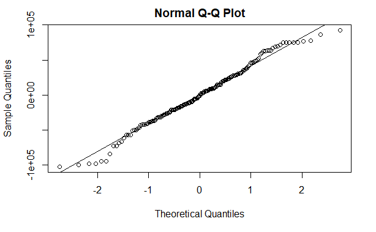

```r
aov_inputlag.pr <- proj(inputlag_anova$aov)
inputlag_res <- aov_inputlag.pr[[3]][, "Residuals"]
qqnorm(inputlag_res); qqline(inputlag_res)
```

```r
# Run Shapiro-Wilk test
shapiro.test(x = inputlag_res )
```

```
    Shapiro-Wilk normality test

data:  inputlag_res
W = 0.98742, p-value = 0.1459
```

Run Levene test for homogeneity of variance across groups

```r
leveneTest(df_list_md$list_input_lags~df_list_md$group)
```

```
Levene's Test for Homogeneity of Variance (center = median)
       Df F value Pr(>F)
group   2   0.843 0.4323
      162
```

The QQplot of the residuals and Levene test for homogenity of variance indicate that the assumptions for ANOVA are met. It is therefore not necessary to transform the data.

```
`fun.y` is deprecated. Use `fun` instead.
```

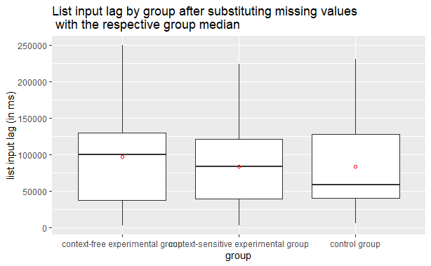

```r
# Boxplot for list input lag by group
ggplot(df_list_md,aes(x = group, y=list_input_lags) ) +
  geom_boxplot() +
  stat_summary(fun.y=mean,shape=1,col='red',geom='point') +
  labs(x="group",
       y = "list input lag (in ms)",
       title="List input lag by group after substituting missing values \n with the respective group median")
```

```
`fun.y` is deprecated. Use `fun` instead.
```

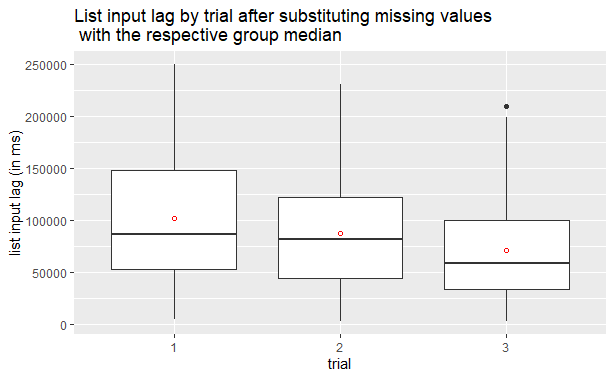

```r
# Boxplot for list input lag by trial
ggplot(df_list_md,aes(x = trial, y=list_input_lags) ) +
  geom_boxplot() +
  stat_summary(fun.y=mean,shape=1,col='red',geom='point') +
  labs(x="trial",
       y = "list input lag (in ms)",
       title="List input lag by trial after substituting missing values \n with the respective group median")
```

Post-hoc tests

```r
pwc_trial <- df_list_md %>%
  pairwise_t_test(
    list_input_lags ~ trial, paired = TRUE,
    p.adjust.method = "holm"
    )
pwc_trial
```

|  | .y. | group1 | group2 | n1 | n2 | statistic | df | p | p.adj | p.adj.signif |
| --- | --- | --- | --- | --- | --- | --- | --- | --- | --- | --- |
| 1 | list_input_lags | 1 | 2 | 55 | 55 | 1.571422 | 54 | 0.122 | 0.214 | ns |
| 2 | list_input_lags | 1 | 3 | 55 | 55 | 2.893041 | 54 | 0.005 | 0.016 | * |
| 3 | list_input_lags | 2 | 3 | 55 | 55 | 1.638939 | 54 | 0.107 | 0.214 | ns |

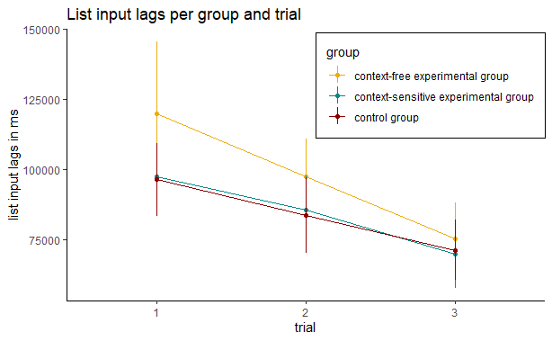

```r
df_list_md %>%
  group_by(trial,group) %>%
  summarise(lil_groups = mean(list_input_lags),
            lil_sem = (sd(list_input_lags)/sqrt(length(list_input_lags)))) -> df_lil
plot_lil = df_lil %>%
  ggplot() +
  aes(x = trial, y = lil_groups, colour = group) +
  theme_classic() +
  geom_line(aes(group = group)) +
  scale_color_manual(values =  c('darkgoldenrod2', 'darkcyan', 'darkred')) +
  geom_point() +
  geom_linerange(aes(x = trial, ymin = lil_groups - lil_sem, ymax = lil_groups + lil_sem), size = .3) +
  theme(legend.justification=c(1,0), legend.position=c(1,0.6), legend.box.background = element_rect(),
  legend.box.margin = margin(4, 4, 4, 4)) +
  labs(title = "List input lags per group and trial", y = "list input lags in ms")
plot_lil
```

### Purposeful action lags

Analyse differences between experimental groups in the time it takes them until the next purposeful action. There are no advantages of log-transforming or inverting the purposeful action lags in terms of the normal distribution chracteristics of the data. Therefore, the analysis of the untransformed values shall be reported. The analysis reveals no significant effects, neither of group nor of trial.

Create dataframe without control group

```r
df_exp <- df_long[!(df_long$group=="control group"),]
```

Convert group and trial to factors

```r
df_exp$group <- factor(df_exp$group)
df_exp$trial <- factor(df_exp$trial)
```

Substitute missing values with group median

```r
df_exp <- df_exp  %>% select(partnr, trial, group, purposeful_action_lags)
list_exp1 <- df_exp$purposeful_action_lags[which(df_exp$group == "context-sensitive experimental group")]
list_exp2 <- df_exp$purposeful_action_lags[which(df_exp$group == "context-free experimental group")]
md_exp1 <- median(list_exp1, na.rm = TRUE)
md_exp2 <- median(list_exp2, na.rm = TRUE)
# replace NA's with median
df_exp$purposeful_action_lags[is.na(df_exp$purposeful_action_lags) & df_exp$group == "context-sensitive experimental group"] <- md_exp1
df_exp$purposeful_action_lags[is.na(df_exp$purposeful_action_lags) & df_exp$group == "context-free experimental group"] <- md_exp2
## check NA's
## missing values per group
aggregate(df_exp$purposeful_action_lags, by= list(df_exp$group),FUN=function(x) {sum(is.na(x))} )
```

| Group.1 | x |
| --- | --- |
| context-free experimental group | 0 |
| context-sensitive experimental group | 0 |

##### Plot the interaction

```r
df_exp %>%
  group_by(trial,group) %>%
  summarise(ppa_groups = mean(purposeful_action_lags),
            ppa_sem = (sd(purposeful_action_lags)/sqrt(length(purposeful_action_lags)))) -> df_ppa
plot_ppa = df_ppa %>%
  ggplot() +
  theme_classic() +
  aes(x = trial, y = ppa_groups, colour = group) +
  geom_line(aes(group = group)) +
  scale_color_manual(values =  c('darkgoldenrod2', 'darkcyan', 'darkred')) +
  geom_point() +
  geom_linerange(aes(x = trial, ymin = ppa_groups - ppa_sem, ymax = ppa_groups + ppa_sem), size = .3) +
  theme(legend.justification=c(1,0), legend.position = c(0.9, 0.7), legend.box.background = element_rect(),
  legend.box.margin = margin(4,4,4,4))
  labs(title = "Purposeful action lags", y = "purposeful action lags in ms")
```

```
$y
[1] "purposeful action lags in ms"

$title
[1] "Purposeful action lags"

attr(,"class")
[1] "labels"
```

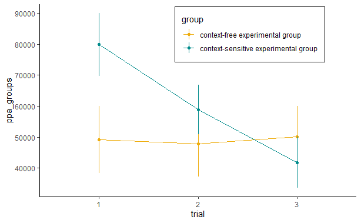

```r
plot_ppa
```

Combine list input lag and purposeful interaction lag plots

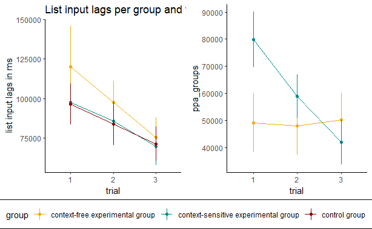

```r
library(ggpubr)
ggarrange(plot_lil, plot_ppa, ncol = 2, common.legend = TRUE, legend = "bottom")
```

##### Boxplot for purposeful action lag by group

```
`fun.y` is deprecated. Use `fun` instead.
```

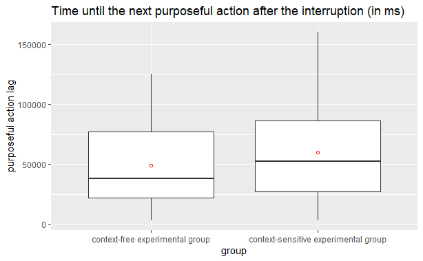

```r
ggplot(df_exp,aes(x = group, y=purposeful_action_lags) ) +
  geom_boxplot() +
  stat_summary(fun.y=mean,shape=1,col='red',geom='point') +
  labs(x="group",
       y = "purposeful action lag",
       title="Time until the next purposeful action after the interruption (in ms)")
```

##### Compute ezANOVA to extract residuals

```r
purposeful_action_lag_anova = ezANOVA(
data = df_exp
, dv = purposeful_action_lags
, wid = partnr
, within = trial
, between = group
, detailed = TRUE
, type = 3
, return_aov = TRUE
)
```

```
You have removed one or more Ss from the analysis. Refactoring "partnr" for ANOVA.Data is unbalanced (unequal N per group). Make sure you specified a well-considered value for the type argument to ezANOVA().
```

```r
anova_out(purposeful_action_lag_anova)
```

```
$`--- ANOVA RESULTS     ------------------------------------`
       Effect        MSE df1 df2      F     p petasq getasq
1 (Intercept) 1660156280   1  32 173.21 0.000   0.84   0.66
2       group 1660156280   1  32   1.80 0.190   0.05   0.02
3       trial 1527322139   2  64   1.83 0.168   0.05   0.04
4 group:trial 1527322139   2  64   1.99 0.145   0.06   0.04

$`--- SPHERICITY TESTS  ------------------------------------`
       Effect p_Mauchly GGEpsilon  p_GG HFEpsilon  p_HF
1       trial     0.481     0.956 0.170     1.015 0.168
2 group:trial     0.481     0.956 0.147     1.015 0.145

$`--- FORMATTED RESULTS ------------------------------------`
       Effect                                   Text
1 (Intercept) F(1, 32) = 173.21, p < .001, np2 = .84
2       group F(1, 32) =   1.80, p = .190, np2 = .05
3       trial F(2, 64) =   1.83, p = .168, np2 = .05
4 group:trial F(2, 64) =   1.99, p = .145, np2 = .06

$`NOTE:`
[1] "No adjustments necessary (all p_Mauchly > 0.05)."
```

Check normal distribution assumption by plotting residuals

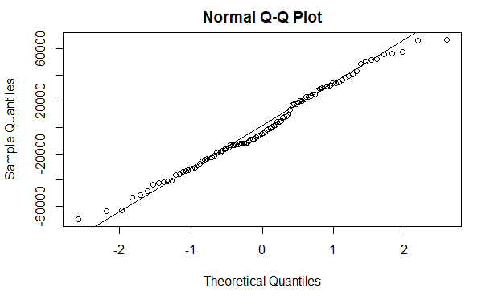

```r
aov_ppa.pr <- proj(purposeful_action_lag_anova$aov)
ppa_res <- aov_ppa.pr[[3]][, "Residuals"]
qqnorm(ppa_res); qqline(ppa_res)
```

Run Shapiro-Wilk test

```r
shapiro.test(df_exp$purposeful_action_lags)
```

```
    Shapiro-Wilk normality test

data:  df_exp$purposeful_action_lags
W = 0.93166, p-value = 5.234e-05
```

Run Levene test for homogeneity of variance across groups

```r
leveneTest(df_exp$purposeful_action_lags~df_exp$group)
```

```
Levene's Test for Homogeneity of Variance (center = median)
       Df F value Pr(>F)
group   1  1.7892 0.1841
      100
```

The Shapiro-Wilk test indicates that the assumptions of normal distribution is not met.

Compute robust ANOVAs

```r
bwtrim(formula = purposeful_action_lags ~ group * trial, id = partnr, data = df_exp)
```

```
Call:
bwtrim(formula = purposeful_action_lags ~ group * trial, id = partnr,
    data = df_exp)
```

|  | value | df1 | df2 | p.value |
| --- | --- | --- | --- | --- |
| group | 1.7202 | 1 | 15.9871 | 0.2082 |
| trial | 1.8436 | 2 | 13.9046 | 0.1949 |
| group:trial | 2.5798 | 2 | 13.9046 | 0.1115 |

```
NA
```

#### Test ANOVA requirements for log-transformed purposeful action lags

log-transform the data

```r
df_exp$ppa_log <- log(df_exp$purposeful_action_lags)
```

Compute ezANOVA to extract residuals

```r
ppa_log_anova = ezANOVA(
data = df_exp
, dv = ppa_log
, wid = partnr
, within = trial
, between = group
, detailed = TRUE
, type = 3
, return_aov = TRUE
)
```

```
You have removed one or more Ss from the analysis. Refactoring "partnr" for ANOVA.Data is unbalanced (unequal N per group). Make sure you specified a well-considered value for the type argument to ezANOVA().
```

```r
anova_out(ppa_log_anova)
```

```
$`--- ANOVA RESULTS     ------------------------------------`
       Effect       MSE df1 df2        F     p petasq getasq
1 (Intercept) 0.9692897   1  32 11023.94 0.000   1.00   0.99
2       group 0.9692897   1  32     1.23 0.276   0.04   0.01
3       trial 0.9465242   2  64     1.27 0.287   0.04   0.03
4 group:trial 0.9465242   2  64     1.88 0.161   0.06   0.04

$`--- SPHERICITY TESTS  ------------------------------------`
       Effect p_Mauchly GGEpsilon  p_GG HFEpsilon  p_HF
1       trial     0.302     0.931 0.286     0.986 0.286
2 group:trial     0.302     0.931 0.164     0.986 0.162

$`--- FORMATTED RESULTS ------------------------------------`
       Effect                                     Text
1 (Intercept) F(1, 32) = 11023.94, p < .001, np2 > .99
2       group F(1, 32) =     1.23, p = .276, np2 = .04
3       trial F(2, 64) =     1.27, p = .287, np2 = .04
4 group:trial F(2, 64) =     1.88, p = .161, np2 = .06

$`NOTE:`
[1] "No adjustments necessary (all p_Mauchly > 0.05)."
```

Check normal distribution assumption by plotting residuals

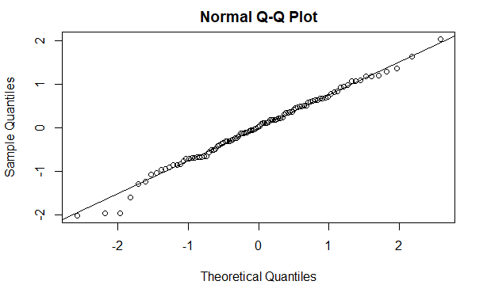

```r
aov_ppa.pr <- proj(ppa_log_anova$aov)
ppa_res <- aov_ppa.pr[[3]][, "Residuals"]
qqnorm(ppa_res); qqline(ppa_res)
```

Run Shapiro-Wilk test

```r
shapiro.test(df_exp$ppa_log)
```

```
    Shapiro-Wilk normality test

data:  df_exp$ppa_log
W = 0.92921, p-value = 3.785e-05
```

Run Levene test for homogeneity of variance across groups

```r
leveneTest(df_exp$ppa_log~df_exp$group)
```

```
Levene's Test for Homogeneity of Variance (center = median)
       Df F value Pr(>F)
group   1   0.014 0.9061
      100
```

Compute robust ANOVAs

```r
bwtrim(formula = ppa_log ~ group * trial, id = partnr, data = df_exp)
```

```
Call:
bwtrim(formula = ppa_log ~ group * trial, id = partnr, data = df_exp)
```

|  | value | df1 | df2 | p.value |
| --- | --- | --- | --- | --- |
| group | 1.2371 | 1 | 15.5696 | 0.2829 |
| trial | 1.2978 | 2 | 12.7464 | 0.3069 |
| group:trial | 2.8835 | 2 | 12.7464 | 0.0927 |

```
NA
```

Plot the interaction

Boxplot for log-transformed purposeful action lags by group

```
`fun.y` is deprecated. Use `fun` instead.
```

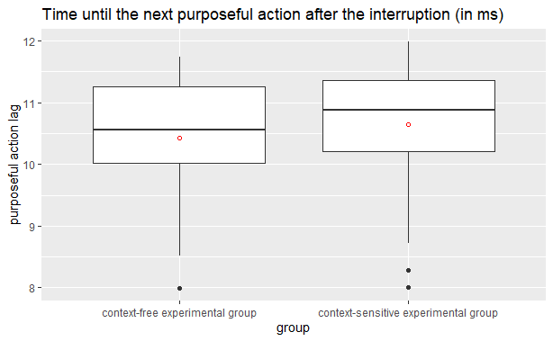

```r
ggplot(df_exp,aes(x = group, y=ppa_log) ) +
  geom_boxplot() +
  stat_summary(fun.y=mean,shape=1,col='red',geom='point') +
  labs(x="group",
       y = "purposeful action lag",
       title="Time until the next purposeful action after the interruption (in ms)")
```

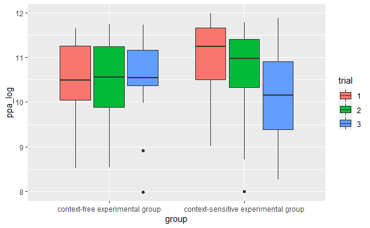

```r
ggplot(aes(y = ppa_log, x = group, fill = trial), data = df_exp) + geom_boxplot()
```

#### Test ANOVA requirements for purposeful action speed

transform the data

```r
df_exp$ppa_speed <- 1/(df_exp$purposeful_action_lags)
```

Compute ezANOVA to extract residuals

```r
ppa_speed_anova = ezANOVA(
data = df_exp
, dv = ppa_speed
, wid = partnr
, within = trial
, between = group
, detailed = TRUE
, type = 3
, return_aov = TRUE
)
```

```
You have removed one or more Ss from the analysis. Refactoring "partnr" for ANOVA.Data is unbalanced (unequal N per group). Make sure you specified a well-considered value for the type argument to ezANOVA().
```

```r
anova_out(ppa_speed_anova)
```

```
$`--- ANOVA RESULTS     ------------------------------------`
       Effect          MSE df1 df2     F     p petasq getasq
1 (Intercept) 3.857340e-09   1  32 56.92 0.000   0.64   0.36
2       group 3.857340e-09   1  32  0.67 0.419   0.02   0.01
3       trial 4.258087e-09   2  64  0.67 0.514   0.02   0.01
4 group:trial 4.258087e-09   2  64  0.76 0.471   0.02   0.02

$`--- SPHERICITY TESTS  ------------------------------------`
       Effect p_Mauchly GGEpsilon  p_GG HFEpsilon  p_HF
1       trial     0.221     0.915 0.502     0.968 0.510
2 group:trial     0.221     0.915 0.461     0.968 0.467

$`--- FORMATTED RESULTS ------------------------------------`
       Effect                                  Text
1 (Intercept) F(1, 32) = 56.92, p < .001, np2 = .64
2       group F(1, 32) =  0.67, p = .419, np2 = .02
3       trial F(2, 64) =  0.67, p = .514, np2 = .02
4 group:trial F(2, 64) =  0.76, p = .471, np2 = .02

$`NOTE:`
[1] "No adjustments necessary (all p_Mauchly > 0.05)."
```

Check normal distribution assumption by plotting residuals

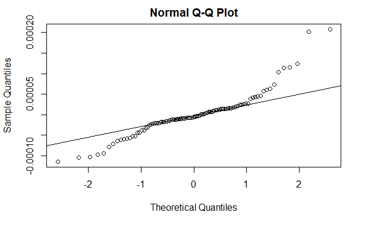

```r
aov_ppa.pr <- proj(ppa_speed_anova$aov)
ppa_res <- aov_ppa.pr[[3]][, "Residuals"]
qqnorm(ppa_res); qqline(ppa_res)
```

Run Shapiro-Wilk test

```r
shapiro.test(df_exp$ppa_speed)
```

```
    Shapiro-Wilk normality test

data:  df_exp$ppa_speed
W = 0.62, p-value = 7.386e-15
```

QQplot of the residuals indicates that the assumption of normal distribution is not met Run levene test for homogeneity of variance across groups

```r
leveneTest(df_exp$ppa_log~df_exp$group)
```

```
Levene's Test for Homogeneity of Variance (center = median)
       Df F value Pr(>F)
group   1   0.014 0.9061
      100
```